```python
from sklearn.feature_extraction.text import HashingVectorizer
from sklearn.linear_model import SGDClassifier, LogisticRegression
from sklearn.metrics import roc_auc_score
from sklearn.model_selection import train_test_split, learning_curve, GridSearchCV, cross_val_score
from sklearn.neighbors import KNeighborsClassifier
from sklearn.linear_model import LogisticRegression, Lasso
from sklearn.ensemble import RandomForestClassifier
from sklearn.svm import SVC
import xgboost as XGB
import pandas as pd
import numpy as np
from bench_util import *
import matplotlib.pyplot as plt
import xgboost as xgb
import re
import seaborn as sns
import _pickle as cPickle
from bs4 import BeautifulSoup
%matplotlib inline
```

# Benchmark TA-60

## Feature Extraction

- 文字: HashVectorizer(1~4-grams) + WordStemming + StopwordsRemoval

## Model

- SGDClassifier: logistic classifer + log-loss with batch_size=1000

```
[2000/27643] done
[4000/27643] done
[6000/27643] done
[8000/27643] done
[10000/27643] done
[12000/27643] done
[14000/27643] done
[16000/27643] done
[18000/27643] done
[20000/27643] done
[22000/27643] done
[24000/27643] done
[26000/27643] done
[28000/27643] done
test auc: 0.5478468782238197
```

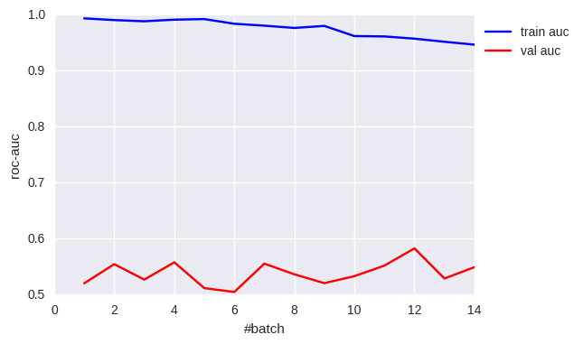

```python
# use HashVectorizer to generate word-frequency features
hashvec = HashingVectorizer(decode_error='ignore', n_features=2**20,
                            ngram_range=(1,4),
                            preprocessor=preprocessor, tokenizer=tokenizer_stem_nostop)
# training by online logistic regression
clf = SGDClassifier(loss='log', n_iter=100)
# set mini-batch size
batch_size = 1000
# generate data stream
stream = get_stream(path='datasets/train_v2.csv', size=batch_size)
classes = np.array([0, 1])
# start training
train_auc, val_auc = [], []
epochs = int((27643+batch_size-1)/(batch_size*2))
for i in range(epochs):
    batch = next(stream)
    X_train, y_train = batch['Page content'], batch['Popularity'].apply(lambda x: 1 if x == 1 else 0)
    if X_train is None:
        break
    X_train = hashvec.transform(X_train)
    clf.partial_fit(X_train, y_train, classes=classes)
    train_auc.append(roc_auc_score(y_train, clf.predict_proba(X_train)[:,1]))
    # validate
    batch = next(stream)
    X_val, y_val = batch['Page content'], batch['Popularity'].apply(lambda x: 1 if x == 1 else 0)
    val_auc.append(roc_auc_score(y_val, clf.predict_proba(hashvec.transform(X_val))[:,1]))
    print('[{}/{}] done'.format((i+1)*(batch_size*2), 27643))

# visualize training history
plt.plot(range(1, len(train_auc)+1), train_auc, color='blue', label='train auc')
plt.plot(range(1, len(train_auc)+1), val_auc, color='red', label='val auc')
plt.legend(loc="upper left", bbox_to_anchor=(1,1))
plt.xlabel('#batch')
plt.ylabel('roc-auc')
# testing
df_test = pd.read_csv('datasets/test_v2.csv')
pred = clf.predict_proba(hashvec.transform(df_test['Page content']))[:,1]
print('test auc: {}'.format(roc_auc_score(df_test['Popularity'], pred)))
# generate submission
df_sub = df_test.drop(['Page content', 'Popularity'], axis=1)
df_sub['Popularity'] = pred
df_sub.to_csv('datasets/bench.csv', index=False)
```

# Benchmark TA-80

## [Feature Engineering] Augmentation

時間

- year: 在那一年發表
- month: 在幾月發表
- day: 在一個月中第幾天發表
- weekday: 星期幾發表
- hour: 一天中哪個小時發表

類型

- channel: 發表在哪個channel
- topic: 內文類型標籤(>=1)
- topic_count: 類型標籤個數

內容

- img_count: 包含幾張圖片
- h2_count: 包含幾個副標題
- link_count: 包含幾個連結
- author_count: 幾個作者
- title: 標題
- title_len: 標題長度

```python
def process(chunk):
    wds, chs, cimg, cvd, ch2, clk, tps, tpns, ts, tls, tlns, aths = [], [], [], [], [], [], [], [], [], [], [], []
    df = chunk.copy().drop('Page content', axis=1)
    df['Popularity'] = df['Popularity'].apply(lambda x: 1 if x==1 else 0)
    for idx, row in chunk.iterrows():
        txt = BeautifulSoup(row['Page content'], 'html.parser')
        content = str(txt.select('section.article-content')[0])
        # weekday
        wds.append(str(txt.select('time')[0]).split('"')[1].split(',')[0])
        # time
        ts.append(str(txt.select('time')[0].get_text()))
        #channel
        chs.append(re.findall('data-channel=\"(.*)\"', row['Page content'])[0].split('"')[0])
        # topic
        tps.append(re.findall('<a href=.*?category\/(.*?)\/', row['Page content']))
        # topic num
        tpns.append(len(re.findall('<a href=.*?category\/(.*?)\/', row['Page content'])))
        # num of img
        cimg.append(len(re.findall('<img', row['Page content'])))
        # num of video
        cvd.append(len(re.findall('<iframe', row['Page content'])))
        # num of h2
        ch2.append(len(re.findall('<h2>', content)))
        # num of links
        clk.append(len(re.findall('<a href', content)))
        # title
        tls.append(str(txt.select('h1.title')[0].get_text()))
        # title length
        tlns.append(len(str(txt.select('h1.title')[0].get_text())))
        # author num
        ath = txt.select('span')
        if len(ath) > 0:
            ath = re.findall('<span.*>(.*)<\/span>', str(ath[0]))[0]
            a = re.findall('<a.*>(.*)<\/a>', ath)
            if len(a) > 0:
                ath = a[0].replace('\r','')
        else:
            ath = 'None'
        aths.append(len(ath.split(',')))
    df['weekday'] = wds
    df['channel'] = chs
    df['img_count'] = cimg
    df['video_count'] = cvd
    df['h2_count'] = ch2
    df['link_count'] = clk
    df['topic_count'] = tpns
    df['topic'] = tps
    df['time'] = ts
    df['title'] = tls
    df['title_len'] = tlns
    df['author_count'] = aths
    return df
def augment(df_path):
    rst = None
    chunksize = 10 ** 3
    for chunk in pd.read_csv(df_path, chunksize=chunksize, encoding='utf-8'):
        tdf = process(chunk)
        rst = tdf if rst is None else pd.concat([rst, tdf])
        print('[{} done]'.format(rst.shape[0]))
    rst['time'] = pd.to_datetime(pd.Series(rst['time']))
    return rst

# augment feature
ext_train = augment('datasets/train_v2.csv')
ext_test = augment('datasets/test_v2.csv')
# extract feature 'year', 'month', 'day', 'hour' from Pandas DatetimeIndex
ext_train['hour'] = pd.DatetimeIndex(ext_train['time']).hour
ext_test['hour'] = pd.DatetimeIndex(ext_test['time']).hour
ext_train['month'] = pd.DatetimeIndex(ext_train['time']).month
ext_test['month'] = pd.DatetimeIndex(ext_test['time']).month
ext_train['day'] = pd.DatetimeIndex(ext_train['time']).day
ext_test['day'] = pd.DatetimeIndex(ext_test['time']).day
ext_train['year'] = pd.DatetimeIndex(ext_train['time']).year
ext_test['year'] = pd.DatetimeIndex(ext_test['time']).year

# backup
ext_train.to_csv('datasets/ext_train_v2.csv', index=False)
ext_test.to_csv('datasets/ext_test_v2.csv', index=False)
```

```
[1000 done]
[2000 done]
[3000 done]
[4000 done]
[5000 done]
[6000 done]
[7000 done]
[8000 done]
[9000 done]
[10000 done]
[11000 done]
[12000 done]
[13000 done]
[14000 done]
[15000 done]
```

[output cut: 25 more lines]

## Explore Data

```python
ext_train = pd.read_csv('datasets/ext_train_v2.csv')
ext_test = pd.read_csv('datasets/ext_test_v2.csv')
ext_train.describe()
```

|  | Id | Popularity | img_count | video_count | h2_count | link_count | topic_count | title_len | author_count | hour | month | day | year |
| --- | --- | --- | --- | --- | --- | --- | --- | --- | --- | --- | --- | --- | --- |
| count | 27643.000000 | 27643.000000 | 27643.000000 | 27643.000000 | 27643.000000 | 27643.000000 | 27643.000000 | 27643.000000 | 27643.000000 | 27643.000000 | 27643.000000 | 27643.000000 | 27643.000000 |
| mean | 13821.000000 | 0.493145 | 5.853923 | 1.262019 | 0.569150 | 10.980610 | 6.957277 | 53.882827 | 1.012878 | 14.030026 | 6.613609 | 15.726368 | 2013.541728 |
| std | 7979.991082 | 0.499962 | 8.324813 | 4.129748 | 2.234762 | 11.310743 | 2.951410 | 11.597389 | 0.118081 | 6.601632 | 3.387915 | 8.629610 | 0.498337 |
| min | 0.000000 | 0.000000 | 0.000000 | 0.000000 | 0.000000 | 0.000000 | 0.000000 | 12.000000 | 1.000000 | 0.000000 | 1.000000 | 1.000000 | 2013.000000 |
| 25% | 6910.500000 | 0.000000 | 2.000000 | 0.000000 | 0.000000 | 4.000000 | 5.000000 | 46.000000 | 1.000000 | 11.000000 | 4.000000 | 8.000000 | 2013.000000 |
| 50% | 13821.000000 | 0.000000 | 2.000000 | 0.000000 | 0.000000 | 7.000000 | 7.000000 | 54.000000 | 1.000000 | 16.000000 | 7.000000 | 16.000000 | 2014.000000 |
| 75% | 20731.500000 | 1.000000 | 6.000000 | 1.000000 | 0.000000 | 14.000000 | 9.000000 | 62.000000 | 1.000000 | 19.000000 | 10.000000 | 23.000000 | 2014.000000 |
| max | 27642.000000 | 1.000000 | 112.000000 | 91.000000 | 59.000000 | 304.000000 | 43.000000 | 112.000000 | 4.000000 | 23.000000 | 12.000000 | 31.000000 | 2015.000000 |

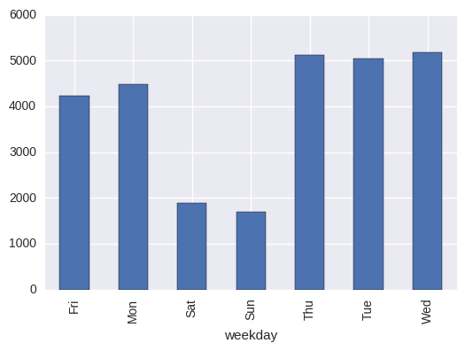

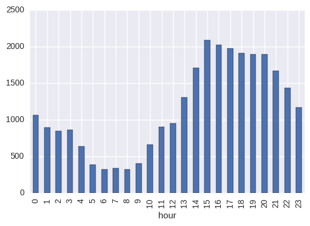

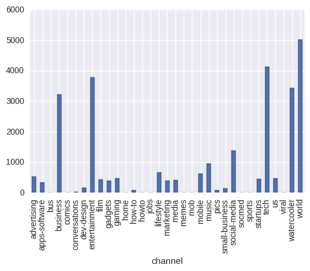

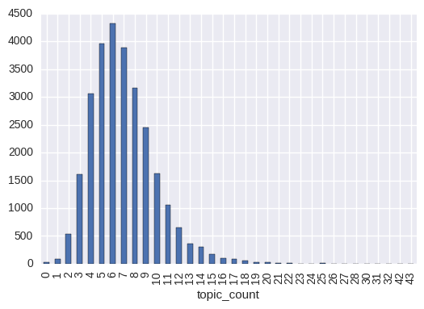

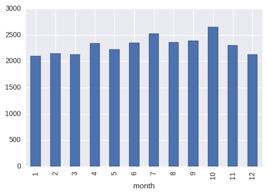

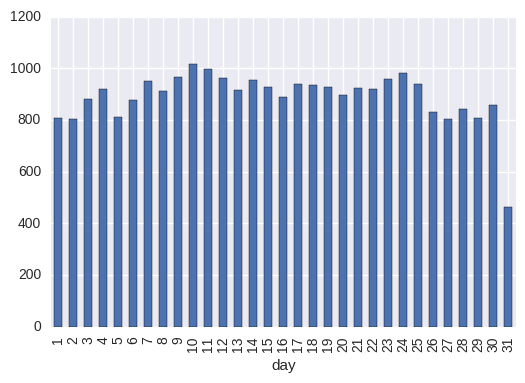

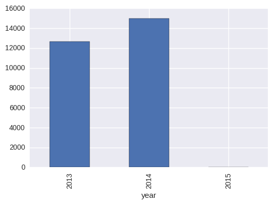

```python
for c in ['weekday', 'hour', 'channel', 'topic_count', 'month', 'day', 'year']:
    ext_train.groupby(c).size().plot(kind='bar')
    plt.savefig('imgs/{}.png'.format(c))
    plt.show()
```

根據觀察，決定新增幾個feature：

- 'weekday': 星期六和星期日，個別發布的新聞比起星期一到五相對少
  - => 新增將星期六和星期日合併的feature: 'Weekend'
- 'hour': 滿分散的
  - => 新增四個時段：'morning', 'afternoon', 'night', 'midnight'
- 'channel': 種類太多
  - => 新增五類channel：'world', 'tech', 'entertainment', 'business', 'lifestyle'

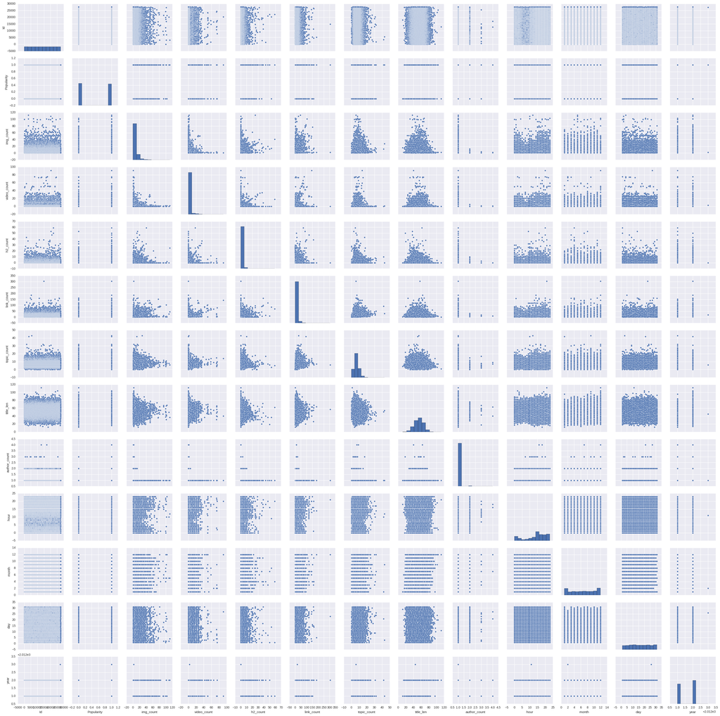

```python
sns.set()
sns_plot = sns.pairplot(ext_train)
sns_plot.savefig("imgs/extracted_pairplot.png")
```

看起來data 很noisy，不過勉強能看出的pattern：

- 'img_counts', 'video_counts', 'link_counts', 'author_counts'：在大過某個數量時，會熱門
- 'title_length'：在大過某個數量時，會不熱門

和平常經驗一致，cool

## [Feature Engineering] Encoding Categorical Features

One-Hot Encoding

- year
- month
- day
- weekday
  - (+) 'Weekend': if 'Sat' or 'Sun'
- hour
  - (+) 'morning': if 7~12h
  - (+) 'afternoon' if 13~18h
  - (+) 'night': if 19~24h
  - (+) 'midnight': if 1~6h
- channel
  - (+) 'world': if 'world', 'us', 'socmed'
  - (+) 'tech': if 'tech', 'watercooler', 'gadgets', 'apps-software', 'mobile', 'dev-design', 'viral', 'mob'
  - (+) 'entertainment': if 'entertainment', 'music', 'gaming', 'pics', 'film', 'sports', 'comics'
  - (+) 'business': if 'startups', 'business', 'marketing', 'bus', 'jobs', 'advertising', 'small-business'
  - (+) 'lifestyle': if 'social-media','media', 'lifestyle', 'how-to', 'conversations', 'home','memes', 'howto'

## [Feature Engineering] Scaling Numerical Features

Standardize

- img_count
- h2_count
- link_count
- author_count
- title_len
- topic_count

```python
# one-hot encode categorical features
def onehot(df_ext):
    df_ext = df_ext.fillna(0)
    wds = df_ext['weekday'].unique()
    chs = df_ext['channel'].unique()
    hs = df_ext['hour'].unique()
    ms = df_ext['month'].unique()
    ds = df_ext['day'].unique()
    ys = df_ext['year'].unique()
    df_aug = df_ext.copy().drop(['weekday',
        'channel', 'topic', 'year', 'month', 'day', 'hour'], axis=1)
    for w in wds:
        df_aug[w] = 0
    df_aug['Weekend'] = 0
    for ch in chs:
        df_aug[ch] = 0
    for m in ms:
        df_aug['M{}'.format(int(m))] = 0
    for d in ds:
        df_aug['d{}'.format(int(d))] = 0
    for y in ys:
        df_aug[y] = 0
    for h in hs:
        df_aug['{}h'.format(int(h))] = 0
    for h in ['morning', 'afternoon', 'night', 'midnight']:
        df_aug[h] = 0
    for i in range(df_aug.shape[0]):
        df_aug.set_value(i, df_ext.iloc[i]['weekday'], 1)
        df_aug.set_value(i, '{}h'.format(int(df_ext.iloc[i]['hour'])), 1)
        df_aug.set_value(i, df_ext.iloc[i]['channel'], 1)
        df_aug.set_value(i, df_ext.iloc[i]['year'], 1)
        df_aug.set_value(i, 'M{}'.format(int(df_ext.iloc[i]['month'])), 1)
        df_aug.set_value(i, 'd{}'.format(int(df_ext.iloc[i]['day'])), 1)
        if df_ext.iloc[i]['weekday'] in ['Sat', 'Sun']:
            df_aug.set_value(i, 'Weekend', 1)
        # aggregate: hour
        if df_ext.iloc[i]['hour'] in range(7, 13):
            df_aug.set_value(i, 'morning', 1)
        elif df_ext.iloc[i]['hour'] in range(13, 19):
            df_aug.set_value(i, 'afternoon', 1)
        elif df_ext.iloc[i]['hour'] in range(19, 24):
            df_aug.set_value(i, 'night', 1)
        else:
            df_aug.set_value(i, 'midnight', 1)
        # aggregate: channel
        if df_ext.iloc[i]['channel'] in ['world', 'us', 'socmed']:
            df_aug.set_value(i, 'world', 1)
        elif df_ext.iloc[i]['channel'] in ['tech', 'watercooler', 'gadgets',
            'apps-software', 'mobile', 'dev-design', 'viral', 'mob']:
            df_aug.set_value(i, 'tech', 1)
        elif df_ext.iloc[i]['channel'] in ['entertainment', 'music', 'gaming',
            'pics', 'film', 'sports', 'comics']:
            df_aug.set_value(i, 'entertainment', 1)
        elif df_ext.iloc[i]['channel'] in ['startups', 'business', 'marketing',
            'bus', 'jobs', 'advertising', 'small-business']:
            df_aug.set_value(i, 'business', 1)
        elif df_ext.iloc[i]['channel'] in ['social-media','media', 'lifestyle',
            'how-to', 'conversations', 'home','memes', 'howto']:
            df_aug.set_value(i, 'lifestyle', 1)
    return df_aug

aug_all = pd.concat([ext_train, ext_test])
print('before encoding col_num: {}'.format(len(aug_all.columns)))
aug_all.set_index('Id', inplace=True)
aug_all = onehot(aug_all)
print('after encoding col_num: {}'.format(len(aug_all.columns)))
aug_train = aug_all.iloc[:ext_train.shape[0]]
aug_test = aug_all.iloc[ext_train.shape[0]:]
aug_test = aug_test.fillna(0)
print('check missing value of train set: {}'.format(aug_train.isnull().T.any().T.sum()))
print('check missing value of test set: {}'.format(aug_test.isnull().T.any().T.sum()))

# scale numerical feature
for c in ['img_count', 'video_count', 'h2_count', 'link_count', 'topic_count', 'author_count', 'title_len']:
    m, std = aug_train[c].mean(), aug_train[c].std()
    aug_train[c] = (aug_train[c]-m) / std
    aug_test[c] = (aug_test[c]-m) / std

# backup
aug_train.to_csv('datasets/alg_train_v2.csv', index=False)
aug_test.to_csv('datasets/alg_test_v2.csv', index=False)

aug_train.describe()
```

```
before encoding col_num: 18
after encoding col_num: 130
check missing value of train set: 0
check missing value of test set: 0
```

|  | Popularity | img_count | video_count | h2_count | link_count | topic_count | title_len | author_count | Wed | Thu | ... | 11h | 12h | 8h | 7h | 6h | 10h | morning | afternoon | night | midnight |
| --- | --- | --- | --- | --- | --- | --- | --- | --- | --- | --- | --- | --- | --- | --- | --- | --- | --- | --- | --- | --- | --- |
| count | 27643.000000 | 2.764300e+04 | 2.764300e+04 | 2.764300e+04 | 2.764300e+04 | 2.764300e+04 | 2.764300e+04 | 2.764300e+04 | 27643.000000 | 27643.000000 | ... | 27643.000000 | 27643.000000 | 27643.000000 | 27643.000000 | 27643.000000 | 27643.000000 | 27643.000000 | 27643.000000 | 27643.000000 | 27643.000000 |
| mean | 0.493145 | -3.791378e-17 | -6.683106e-18 | 2.133453e-17 | -3.984160e-17 | 3.084511e-17 | -9.664800e-17 | -2.398207e-16 | 0.187389 | 0.185291 | ... | 0.032486 | 0.034511 | 0.011649 | 0.012300 | 0.011576 | 0.023876 | 0.129436 | 0.397931 | 0.291647 | 0.180986 |
| std | 0.499962 | 1.000000e+00 | 1.000000e+00 | 1.000000e+00 | 1.000000e+00 | 1.000000e+00 | 1.000000e+00 | 1.000000e+00 | 0.390231 | 0.388541 | ... | 0.177289 | 0.182542 | 0.107300 | 0.110222 | 0.106970 | 0.152665 | 0.335688 | 0.489480 | 0.454529 | 0.385014 |
| min | 0.000000 | -7.031897e-01 | -3.055924e-01 | -2.546802e-01 | -9.708124e-01 | -2.357272e+00 | -3.611401e+00 | -1.090649e-01 | 0.000000 | 0.000000 | ... | 0.000000 | 0.000000 | 0.000000 | 0.000000 | 0.000000 | 0.000000 | 0.000000 | 0.000000 | 0.000000 | 0.000000 |
| 25% | 0.000000 | -4.629441e-01 | -3.055924e-01 | -2.546802e-01 | -6.171663e-01 | -6.631666e-01 | -6.797071e-01 | -1.090649e-01 | 0.000000 | 0.000000 | ... | 0.000000 | 0.000000 | 0.000000 | 0.000000 | 0.000000 | 0.000000 | 0.000000 | 0.000000 | 0.000000 | 0.000000 |
| 50% | 0.000000 | -4.629441e-01 | -3.055924e-01 | -2.546802e-01 | -3.519318e-01 | 1.447555e-02 | 1.010335e-02 | -1.090649e-01 | 0.000000 | 0.000000 | ... | 0.000000 | 0.000000 | 0.000000 | 0.000000 | 0.000000 | 0.000000 | 0.000000 | 0.000000 | 0.000000 | 0.000000 |
| 75% | 1.000000 | 1.754715e-02 | -6.344681e-02 | -2.546802e-01 | 2.669489e-01 | 6.921177e-01 | 6.999138e-01 | -1.090649e-01 | 0.000000 | 0.000000 | ... | 0.000000 | 0.000000 | 0.000000 | 0.000000 | 0.000000 | 0.000000 | 0.000000 | 1.000000 | 1.000000 | 0.000000 |
| max | 1.000000 | 1.275057e+01 | 2.172965e+01 | 2.614634e+01 | 2.590629e+01 | 1.221203e+01 | 5.011229e+00 | 2.529724e+01 | 1.000000 | 1.000000 | ... | 1.000000 | 1.000000 | 1.000000 | 1.000000 | 1.000000 | 1.000000 | 1.000000 | 1.000000 | 1.000000 | 1.000000 |

8 rows × 128 columns

```python
aug_train = aug_train.drop(['time', 'title'], axis=1)
aug_test = aug_test.drop(['time', 'title'], axis=1)

X_train = aug_train.drop(['Popularity'], axis=1)
X_test = aug_test.drop(['Popularity'], axis=1)
y_train = aug_train['Popularity']
y_test = aug_test['Popularity']

clf1 = LogisticRegression(penalty='l1', C=1e-1)
clf2 = RandomForestClassifier(n_estimators=50)
clf3 = KNeighborsClassifier(n_neighbors=5, weights='uniform')
clf4 = SVC(kernel='poly', probability=True, C=35, gamma=0.0055, coef0=0.1, degree=2)

print('[LR] CV-score: {}'.format(cross_val_score(clf1, X_train, y_train).mean()))
print('[RF] CV-score: {}'.format(cross_val_score(clf2, X_train, y_train).mean()))
print('[KNN] CV-score: {}'.format(cross_val_score(clf3, X_train, y_train).mean()))
print('[SVC] CV-score: {}'.format(cross_val_score(clf4, X_train, y_train).mean()))
```

```
[LR] CV-score: 0.5632528495978523
[RF] CV-score: 0.5470461979523246
[KNN] CV-score: 0.5318524230213736
[SVC] CV-score: 0.5641572900360837
```

## [Feature Engineering] Extracting Text Feature

以下幾種方法產生的文字feature，performance 都差不多(純文字：0.53、加上augment feature：0.57+)

- Latent Semantic Indexing: Tf-Idf + SVD (註：必須batch地轉換)
  - best-dimension: 100
- Topic Modeling: Latent Dirichlet Allocation
  - best-dimension: 50
- Document Embedding: doc2vec
  - best-dimension: 16

TA-80 使用 gensim 的 doc2vec，不久lab 課會教到。

```python
import gensim

def remove(text):
    text = preprocessor(text)
    return text.replace('\n', ' ')

def read_corpus(fname, tokens_only=False):
    with open(fname, encoding='utf-8') as f:
        for i, line in enumerate(f):
            if tokens_only:
                yield gensim.utils.simple_preprocess(line)
            else:
                yield gensim.models.doc2vec.TaggedDocument(gensim.utils.simple_preprocess(line), [i])
# read dataset
df_train, df_test = pd.read_csv('datasets/train_v2.csv'), pd.read_csv('datasets/test_v2.csv')
df_train['Popularity'] = df_train['Popularity'].apply(lambda x: 1 if x==1 else 0)
# prepare documents for gensim
s_train = '\n'.join(df_train['Page content'].apply(remove))
with open('datasets/page_train.txt', 'w+') as f:
    f.write(s_train)
s_test = '\n'.join(df_test['Page content'].apply(remove))
with open('datasets/page_test.txt', 'w+') as f:
    f.write(s_test)
# training Doc2Vec
train_corpus = list(read_corpus('datasets/page_train.txt'))
test_corpus = list(read_corpus('datasets/page_test.txt'))
model = gensim.models.doc2vec.Doc2Vec(size=16, min_count=1, iter=10)
model.build_vocab(train_corpus)
%time model.train(train_corpus)
# get mapped vector
inf_train = []
for doc_id in range(len(train_corpus)):
    inferred_vector = model.infer_vector(train_corpus[doc_id].words)
    inf_train.append(inferred_vector)
inf_test = []
for doc_id in range(len(test_corpus)):
    inferred_vector = model.infer_vector(test_corpus[doc_id].words)
    inf_test.append(inferred_vector)
# backup
cPickle.dump(inf_train, open('datasets/d2v_page_train.pkl', 'wb'))
cPickle.dump(inf_test, open('datasets/d2v_page_test.pkl', 'wb'))
```

```
WARNING (theano.sandbox.cuda): CUDA is installed, but device gpu0 is not available  (error: Unable to get the number of gpus available: unknown error)
```

```
CPU times: user 4min 9s, sys: 3.03 s, total: 4min 12s
Wall time: 4min 8s
```

## Augmented Features + Text Feature

```python
pg_train, pg_test = cPickle.load(open('datasets/d2v_page_train.pkl','rb')), cPickle.load(open('datasets/d2v_page_test.pkl','rb'))
df_train = pd.read_csv('datasets/alg_train_v2.csv').drop(['time', 'title'], axis=1)
df_test = pd.read_csv('datasets/alg_test_v2.csv').drop(['time', 'title'], axis=1)
X_train = np.hstack([df_train.drop(['Popularity'], axis=1), pg_train])
X_test = np.hstack([df_test.drop(['Popularity'], axis=1), pg_test])
y_train = df_train['Popularity']
y_test = df_test['Popularity']
```

## Model: Weighted-Sum Voting

- Logistic Regression
- Random Forest
- SVM
- KNN
- Lasso

```python
X_trainS, X_val, y_trainS, y_val = train_test_split(X_train, y_train, test_size=0.3)

clf1 = LogisticRegression(penalty='l1', C=1)
clf2 = RandomForestClassifier(n_estimators=100)
clf3 = SVC(kernel='poly', probability=True, C=35, gamma=0.0055, coef0=0.1, degree=2)
clf4 = KNeighborsClassifier(n_neighbors=5)
clf5 = Lasso(alpha=1e-4, max_iter=50000)

clf1.fit(X_trainS, y_trainS)
clf2.fit(X_trainS, y_trainS)
clf3.fit(X_trainS, y_trainS)
clf4.fit(X_trainS, y_trainS)
clf5.fit(X_trainS, y_trainS)

pred1 = clf1.predict_proba(X_val)[:,1]
pred2 = clf2.predict_proba(X_val)[:,1]
pred3 = clf3.predict_proba(X_val)[:,1]
pred4 = clf4.predict_proba(X_val)[:,1]
pred5 = clf5.predict(X_val)

print('[LR] valid-auc: {}'.format(roc_auc_score(y_val, pred1)))
print('[RF] valid-auc: {}'.format(roc_auc_score(y_val, pred2)))
print('[SVC] valid-auc: {}'.format(roc_auc_score(y_val, pred3)))
print('[KNN] valid-auc: {}'.format(roc_auc_score(y_val, pred4)))
print('[Lasso] valid-auc: {}'.format(roc_auc_score(y_val, pred5)))

# select voting weight by validation set
bab, bscore = None, 0
for a in range(10):
    for b in range(10):
        for c in range(10):
            for d in range(10):
                for e in range(10):
                    y_pred = pred1*a + pred2*b + pred3*c + pred4*d + pred5*e
                    s = roc_auc_score(y_val, y_pred)
                    if bscore < s:
                        bab = (a, b, c, d, e)
                        bscore = s
print('{}: {}'.format(bab, bscore))

# train on all training data
clf1.fit(X_train, y_train)
clf2.fit(X_train, y_train)
clf3.fit(X_train, y_train)
clf4.fit(X_train, y_train)
clf5.fit(X_train, y_train)

# testing
pred1 = clf1.predict_proba(X_test)[:,1]
pred2 = clf2.predict_proba(X_test)[:,1]
pred3 = clf3.predict_proba(X_test)[:,1]
pred4 = clf4.predict_proba(X_test)[:,1]
pred5 = clf5.predict(X_test)

a, b, c, d, e = bab
y_pred = pred1*a + pred2*b + pred3*c + pred4*d + pred5*e
s = roc_auc_score(y_test, y_pred)
print('test auc: {}'.format(s))

df_sub = pd.read_csv('datasets/sample_submission_v2.csv')
df_sub['Popularity'] = y_pred
df_sub.to_csv('datasets/bench-80.csv', index=False)
```

[output not shown]

```
[LR] valid-auc: 0.5676093911789002
[RF] valid-auc: 0.5717290554140052
[SVC] valid-auc: 0.576885798052424
[KNN] valid-auc: 0.5424217013949484
[Lasso] valid-auc: 0.5677738996893651
(0, 5, 7, 1, 0): 0.5843754144706991
```